# Top income earners in Finland

Kyle Ott and Cornelius Schneider

December 12, 2014

**Since 2009, Finland’s largest business online daily newspaper [Taloussanomat](http://www.taloussanomat.fi) publishes the top 15,000 income earners who are 18 years or older. The data includes their name, total income, taxed paid, and their average tax rate.**

[figure not shown]

(source: screenshot of [Taloussanomat website](http://www.taloussanomat.fi/verotiedot/2009/suurituloisimmat/))  
*Until now*, this information has been provided in tables that are in an unsatifactory format. To advance the transparency and openess of the data, we (researchers) have scraped the [raw data](https://github.com/kylejott/Final_Project/blob/master/all.RData) that has so far been published (the years 2009 to 2013) and cleaned it so that you can take a look at all 70,402 tax payer information in one [dataset](https://github.com/kylejott/Final_Project/blob/master/clean.RData).

We have reached out to *Taloussanomat*, but have not heard back from them for official comment. **Our purpose for doing this project is for academic purposes**, of which we have written a paper entitled *The Top (0.4%) Tail of Finland: A Tale of Incomes, Tax Rates, and Elasticities from 2009 to 2013* which you can find a pdf version [here](https://github.com/kylejott/Final_Project/blob/master/final_paper.pdf).

**Our intent for this website, is serve as a portal for information about this dataset on Finland’s top income-earners.** All of our code is located in an [open repository](https://github.com/kylejott/Final_Project) of which we welcome others to contribute and make comments. Other than finding links, this website also presents summary information about the dataset, which is lacking on the Taloussanomat website.

## Data Overview

In a first step, we [scraped the data](https://github.com/kylejott/Final_Project/blob/master/data_scraping.R) from the *Taloussanomat* [dedicated website](http://www.taloussanomat.fi/verotiedot/2009/suurituloisimmat/).

The variables given by our scraped data are as follows: full name, total income (in euros), total taxes paid (in euros), average tax rate (in percent), and the tax year. Note that the lowest income observed in our data is 150,002 euros while the highest is 170,127,542 euros. The following table provides a quick overview:

| Year | # of obs | Ave Inc | Median Inc | Ave Taxes Paid | Median Taxes Paid | Ave Tax | Med Tax |
| --- | --- | --- | --- | --- | --- | --- | --- |
| 2009 | 12134 | 283245 | 199020 | 106996 | 80653 | 40 | 43 |
| 2010 | 14290 | 305270 | 201964 | 111710 | 80336 | 39 | 42 |
| 2011 | 13978 | 350746 | 219372 | 128043 | 87256 | 40 | 44 |
| 2012 | 15000 | 285234 | 202520 | 112169 | 83368 | 41 | 43 |
| 2013 | 15000 | 347759 | 213323 | 136092 | 89515 | 42 | 44 |
| All | 70402 | 315287 | 207456 | 119433 | 84494 | 40 | 43 |

Below you will see a plot showing the counts of the average tax rates paid by the ultra-wealthy. As you might expect, most pay a very high rate.

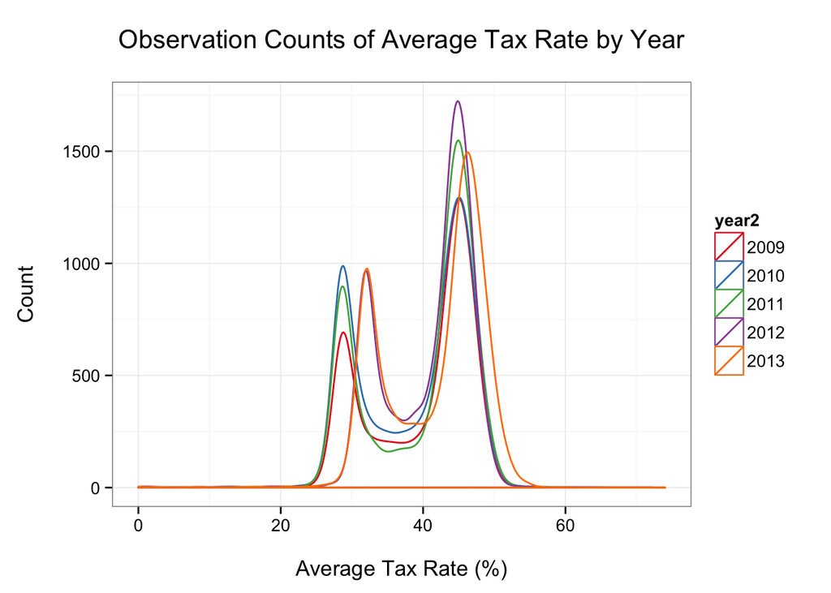

The next three plots can be thought of as being stacked on top of each other as they break the top income earners into three income tiers (the lower, middle, and upper).

The first graph plots the average tax rate paid against an individual’s total a annual taxable income. The next plot looks at incomes between 1 million and 5 million euros. The third plot looks at incomes greater than 5 million euros.

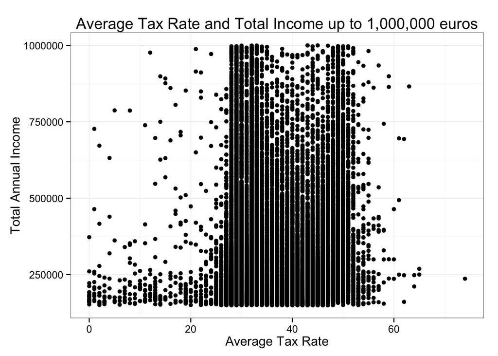

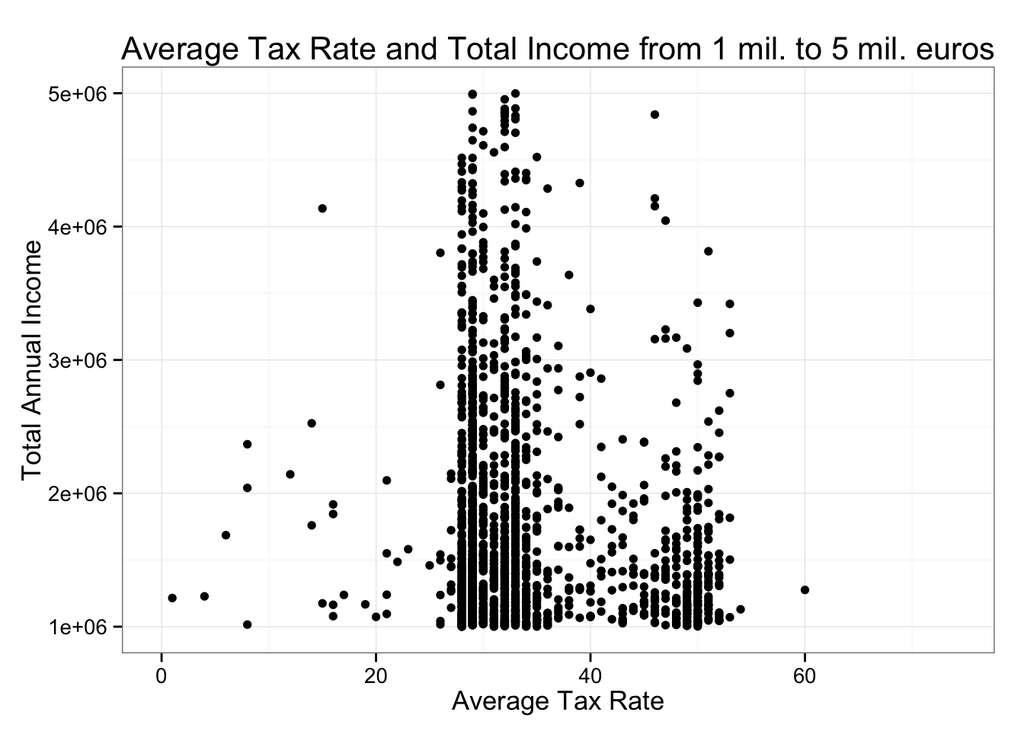

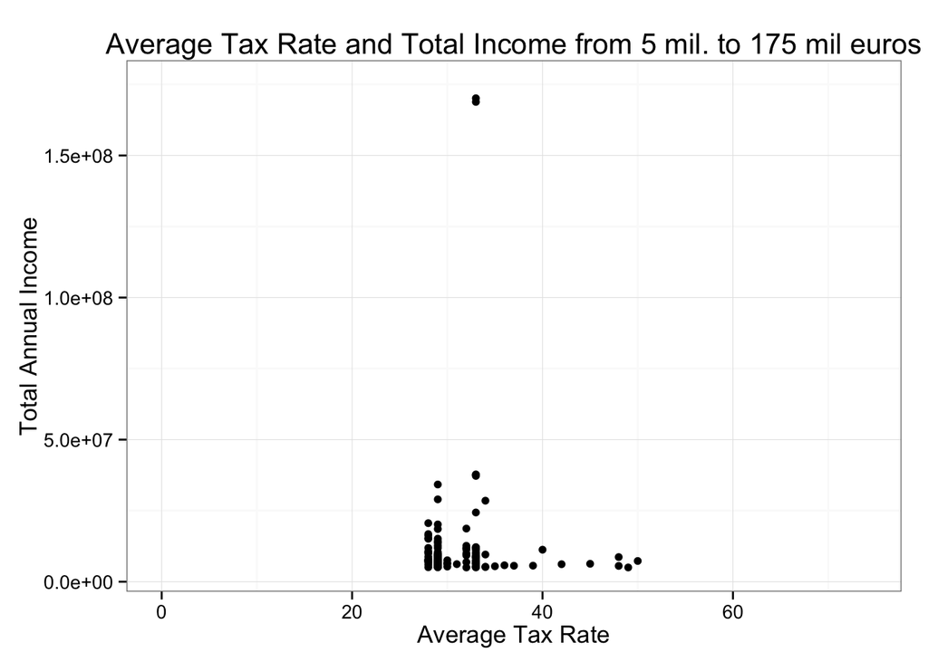

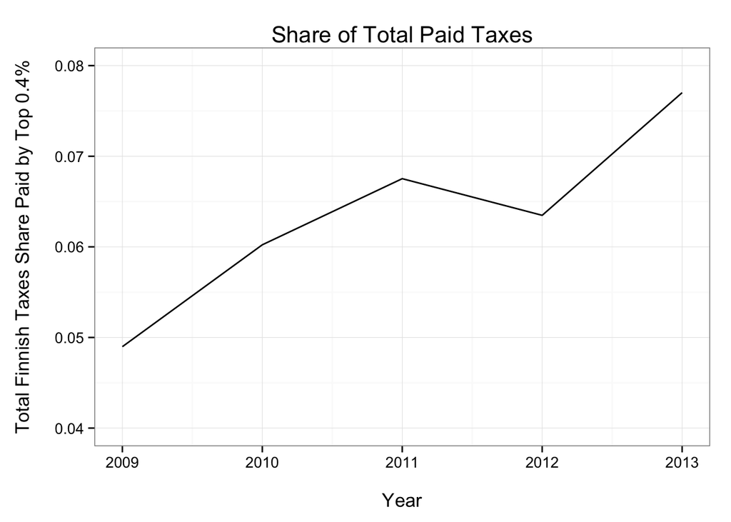

Our final plot goes out to fans of statistics and serves as a nudge to continue reading [our research](https://github.com/kylejott/Final_Project/blob/master/final_paper.pdf). It simply plots the distributions of logged taxable income across our five years.

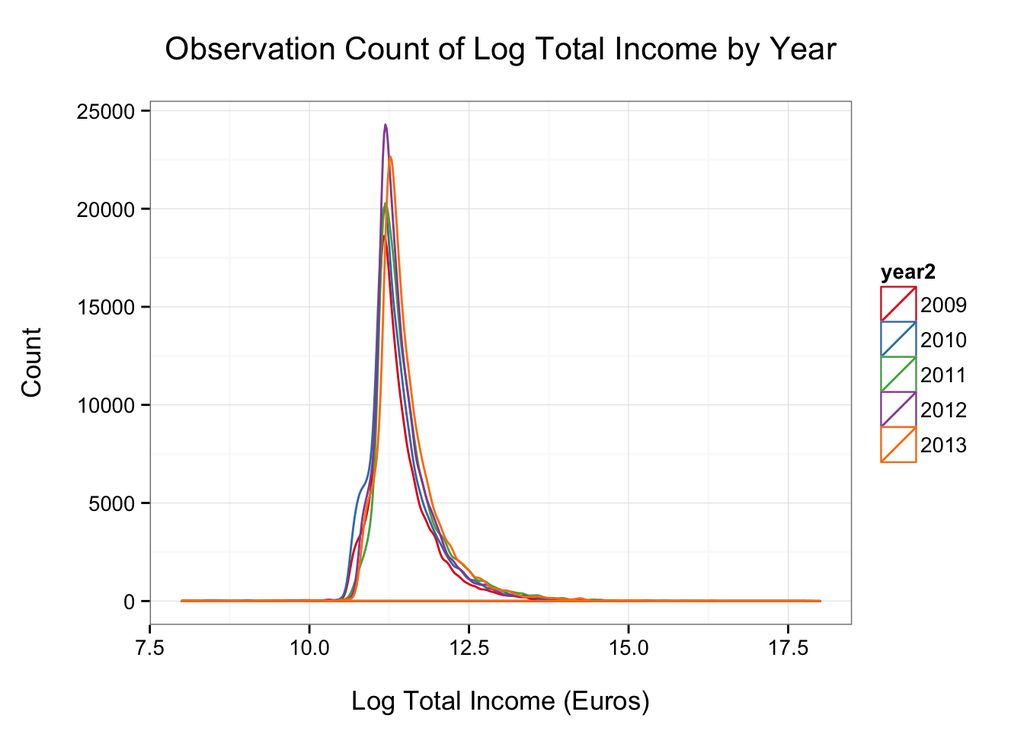

## Final Thoughts

We are inspired by the work of top tax economists that has been spearheaded by [Thomas Piketty](http://piketty.pse.ens.fr/en/) who is behind the *World Top Income Database* which is found [here](http://topincomes.parisschoolofeconomics.eu/). We encourage you to take a look at this website if you are interested in the very limited amount (but very important) work underway on understanding behovoiral changes of top income earners.

Thanks for reading our website!